# gradient_descent

Gradient Descent Algorithm

Linear Regression

In linear setting, the loss function that needs to be minimized is MSE. A way to reach the goal of minimizing MSE is by selecting the right coefficients. Because linear regression is unbiased estimator, it has an unique form of solution when it's full rank.

However, unconder conditions like full rank is not met, gradient descent algorithm can be used to find coefficients that may minimize MSE to some degrees. A caveat to this is that it's not the global minimum as gradient descent algorithm stops when no further progress is made.

Steps over view

1. start with random initial parameters(coefficients)
2. update parameters with taking small steps in a direction that is opposite of the loss function.
3. repeat steps 1 and 2 until desired goal is met

```python
import pandas as pd
import numpy as np
import matplotlib.pyplot as plt
from sklearn.datasets import load_iris

# Data Setup
x1 = np.random.normal(size=1000) # first variable
x2 = x1**2 #second variable
y = 10 +3*x1 + 5*x2 +np.random.normal(size=1000)
```

The plot below is the scatter plot of the artifically created data. As shown in the plot, this x and y has polynomial relationship. The value of y-intecept is 10, coefficients are 3 and 5 for x1 and x2, respectively.

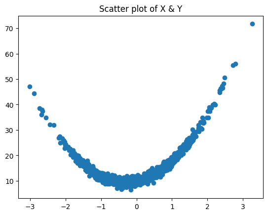

```python
plt.scatter(x1,y)
plt.title('Scatter plot of X & Y')
plt.show()
```

Let's try to estimate coefficients.

```python
# Initial parameters
learning_rate = 0.01 # taking a small step
# starting all coefficients estimates at 5
b0 = 5
b1 = 5
b2 = 5

# terms related in the loop
max_iter = 10000
iter = 0
pred = b0 + x1*b1 + x2*b2 # equation of y
mse = 100

mse_hist = []
b0_hist = []
b1_hist = []
b2_hist = []

# This loop is running until MSE <=1
while mse >1 and iter<=max_iter:
    pred = b0 + x1*b1 + x2*b2 # prediction
    diff = (pred-y) #difference of pred - y a.k.a error or residual
    mse = (np.mean(diff**2)) # mse
    n = len(y) # length of y

    # parameter update
    # this is where calculus is involved, going opposite direction to minimize it.
    b0 -= learning_rate*np.sum(diff)/n
    b1 -= learning_rate*np.dot(diff,x1)/n
    b2 -= learning_rate*np.dot(diff,x2)/n

    mse_hist.append(mse)
    b0_hist.append(b0)

    iter+=1

print(f'Y-intercept is {b0}', f'X1 coefficient is {b1}', f'X2 coeffcient is {b2}')
```

```
Y-intercept is 9.976073363504831 X1 coefficient is 3.007899614270689 X2 coeffcient is 5.022400380814248
```

The output above shows that the estimated parameters are 9.97,3.01, and 5.02 for y-intercept,x1,and x2,respectively. Which is fairly close.

Logistic Regression

Logistic Regression is slightly more complicated than linear regression b/c of its characteristic of bounding the output between 0 and 1. This is done using a sigmoid function. Additionally, for simplicitly, linear algebra is used to instead of calculating one by one. Also, instead of MSE, log loss is the loss function. This function is slightly harder to compute derivative to go opposite direction but all steps are same.

Additionally, logistic regression is like simplified version of neural network which is the reason why this exercise is conducted. It is performed to practice neural network.

Data used is iris data from sklearn. To make it a binary classification problem which logistic regression is suited for, a logistic regression model to predict Satosa is created.

```python
# Data
iris= load_iris() #Loading iris data
X = iris.data
X = np.hstack([np.ones((X.shape[0], 1 )), X]) #adding a y-intercept term
y = np.where(iris.target==0,1,0) # Target: 0 (Setosa), 1 (Versicolor), 2 (Virginica) # 1 if Satosa else 0

#Unlike linear gression, sigmoid function is needed to bound the output between 0 and 1
def sigmoid(z):
    y_prob = 1/(1+np.exp(-z))
    return y_prob


learning_rate = 0.001
w = np.random.normal(size=X.shape[1]) #initial weights
loss_hist =[]
def sigmoid(z):
    y_prob = 1/(1+np.exp(-z))
    return y_prob

for iter in range(max_iter):
    n = len(X)
    z = np.dot(X,w) #linear combination of the data and coefficients, just like regression function
    y_pred = sigmoid(z) # transforming z into sigmoid to make it bound between 0 and 1
    res = y_pred - y
    loss = -y*np.log(y_pred)-(1-y)*np.log(1-y_pred) #logloss
    loss_t = np.sum(loss) / n
    gradients = np.dot(X.T,res)/ n # this formula is the result of doing derivatives of log loss using chain rule

    #parameter update
    w -= learning_rate*gradients
    loss_hist.append(loss_t)

print(f'Parameters are {w}')
```

```
Parameters are [-0.22295203 -0.35753022  1.80774594 -0.94970925 -1.19078927]
```

[figure not shown]

```python
plt.plot(range(len(loss_hist)),loss_hist)
plt.title('Log Loss for each iteration')
```

Below is checking the performance of logistic regression on the training data (entire IRIS dataset). It achieved 100% accuracy.

```python
type_pred = np.where(sigmoid(np.dot(X,w))>0.5,1,0)
np.sum(type_pred == y)/len(y)
```

```
np.float64(1.0)
```